# 22125096_Two-Way-Anova

## Set up the data

```r
data <- read.csv("insurance.csv")
dim(data)
```

```
## [1] 1338    7
```

```r
head(data)
```

|  | age | sex | bmi | children | smoker | region | charges |
| --- | --- | --- | --- | --- | --- | --- | --- |
| 1 | 19 | female | 27.900 | 0 | yes | southwest | 16884.924 |
| 2 | 18 | male | 33.770 | 1 | no | southeast | 1725.552 |
| 3 | 28 | male | 33.000 | 3 | no | southeast | 4449.462 |
| 4 | 33 | male | 22.705 | 0 | no | northwest | 21984.471 |
| 5 | 32 | male | 28.880 | 0 | no | northwest | 3866.855 |
| 6 | 31 | female | 25.740 | 0 | no | southeast | 3756.622 |

```r
str(data)
```

```
## 'data.frame':    1338 obs. of  7 variables:
##  $ age     : int  19 18 28 33 32 31 46 37 37 60 ...
##  $ sex     : chr  "female" "male" "male" "male" ...
##  $ bmi     : num  27.9 33.8 33 22.7 28.9 ...
##  $ children: int  0 1 3 0 0 0 1 3 2 0 ...
##  $ smoker  : chr  "yes" "no" "no" "no" ...
##  $ region  : chr  "southwest" "southeast" "southeast" "northwest" ...
##  $ charges : num  16885 1726 4449 21984 3867 ...
```

```r
attach(data)
```

## Process

```r
data$sex <- as.factor(data$sex)
data$smoker <- as.factor(data$smoker)
levels(data$sex) #the levels() function to extract the levels of a factor variable.
```

```
## [1] "female" "male"
```

```r
levels(data$smoker)
```

```
## [1] "no"  "yes"
```

### Interaction plot

Create interaction plots: to consider the interaction between these factors.  
If there is an intersection between lines or different lines go in different path $\to$ Interaction.  
Parallel lines $\to$ No interaction.

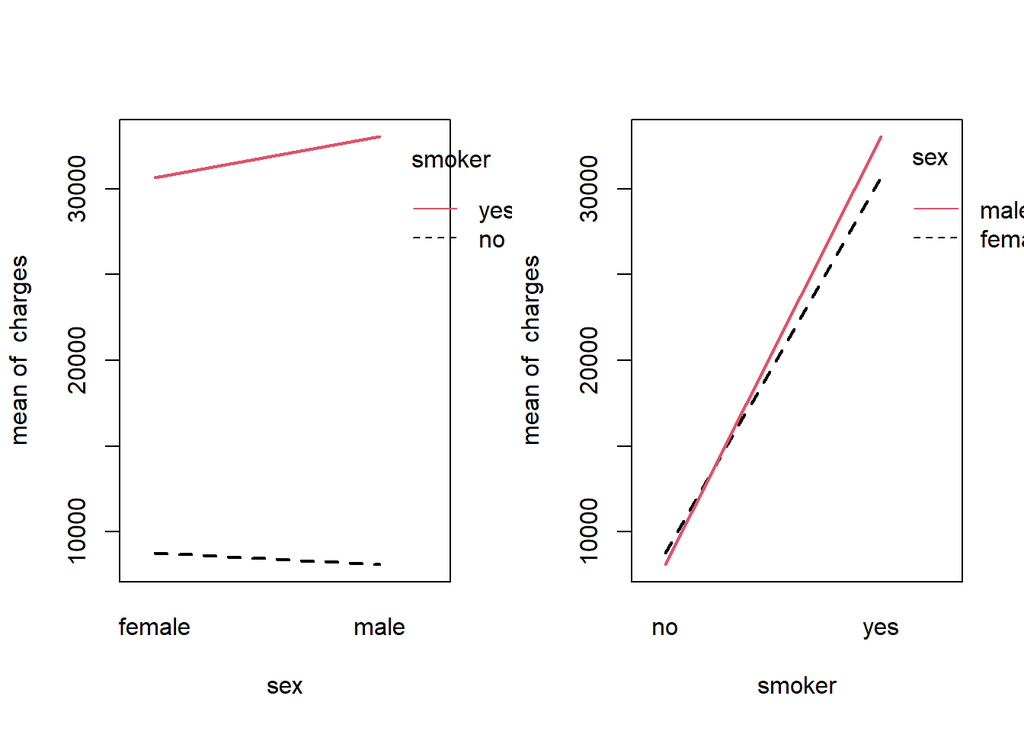

```r
par(mfrow = c(1, 2))
with(data, interaction.plot(sex, smoker, charges, lwd = 2, col = 1:4))
with(data, interaction.plot(smoker, sex, charges, lwd = 2, col = 1:3))
```

Smoking Impact: Smoking has a strong effect on mean charges, with smokers facing higher costs regardless of gender.  
Sex Impact: The influence of gender on charges is more evident among smokers, where male smokers tend to have higher charges than female smokers.  
Interaction Effect: There seems to be a moderate interaction between gender and smoking, with male smokers experiencing the highest charges.

### Fit model

```r
model_int = aov(charges ~ sex * smoker) # interaction model
model_add = aov(charges ~ sex + smoker) # additive model
model_sex = aov(charges ~ sex) # single factor model
model_smoker = aov(charges ~ smoker) # single factor model
model_null = aov(charges ~ 1) # null model
summary(model_int)
```

```
##               Df    Sum Sq   Mean Sq  F value   Pr(>F)
## sex            1 6.436e+08 6.436e+08   11.593 0.000682 ***
## smoker         1 1.209e+11 1.209e+11 2177.284  < 2e-16 ***
## sex:smoker     1 4.923e+08 4.923e+08    8.868 0.002954 **
## Residuals   1334 7.406e+10 5.552e+07
## ---
## Signif. codes:  0 '***' 0.001 '**' 0.01 '*' 0.05 '.' 0.1 ' ' 1
```

From the summary table, we can obtain:  
sex: The p-value (0.000682) is very small, indicating that sex has a statistically significant effect on charges.  
smoker: The p-value (< 2e-16) shows that smoker has an extremely significant effect on charges.  
sex:smoker: The p-value (0.002954) show that the interaction between sex and smoker is also statistically significant, meaning the combined effect of sex and smoker on charges is significant.

```r
summary(model_add)
```

```
##               Df    Sum Sq   Mean Sq F value   Pr(>F)
## sex            1 6.436e+08 6.436e+08   11.53 0.000707 ***
## smoker         1 1.209e+11 1.209e+11 2164.53  < 2e-16 ***
## Residuals   1335 7.455e+10 5.584e+07
## ---
## Signif. codes:  0 '***' 0.001 '**' 0.01 '*' 0.05 '.' 0.1 ' ' 1
```

From the summary table of model_add, we observe that:  
sex is significant with a p-value of 0.000707.  
smoker remains extremely significant with a p-value of < 2e-16.  
From both summaries, we notice that the residuals in the interaction model are slightly smaller, suggesting that this model might explain the variation in charges better than the additive model.

### Table of factor

```r
factor_table = expand.grid(sex = unique(data$sex), smoker = unique(data$smoker))
factor_table
```

| sex | smoker |
| --- | --- |
| female | yes |
| male | yes |
| female | no |
| male | no |

```r
matrix(paste0(factor_table$sex, "-", factor_table$smoker) , 2, 2, byrow = TRUE)
```

```
##      [,1]         [,2]
## [1,] "female-yes" "male-yes"
## [2,] "female-no"  "male-no"
```

```r
##Function to perform the prediction.
get_est_means = function(model, table) {
mat = matrix(predict(model, table), nrow = 2, ncol = 2, byrow = TRUE)
colnames(mat) = c("female", "male")
rownames(mat) = c("smoker", "non-smoker")
mat
}
```

### Prediction from model

```r
#The estimates from the interaction model
knitr::kable(get_est_means(model = model_int, table = factor_table))
```

|  | female | male |
| --- | --- | --- |
| smoker | 30678.996 | 33042.006 |
| non-smoker | 8762.297 | 8087.205 |

```r
#The estimates from the additive model.
knitr::kable(get_est_means(model = model_add, table = factor_table))
```

|  | female | male |
| --- | --- | --- |
| smoker | 32088.170 | 32022.792 |
| non-smoker | 8466.036 | 8400.657 |

Interaction model:  
The interaction model indicates that the effect of sex on charges is influenced by smoking status. This is clear from the varying estimated charges between males and females when comparing smokers and non-smokers.  
Smoking males have higher estimated charges than smoking females, while among non-smokers, the estimated charges for both sexes are more similar and noticeably lower.

```r
#The estimates from the additive model.
knitr::kable(get_est_means(model = model_add, table = factor_table))
```

|  | female | male |
| --- | --- | --- |
| smoker | 32088.170 | 32022.792 |
| non-smoker | 8466.036 | 8400.657 |

Additive model:  
The additive model implies that the effects of sex and smoking status are independent of each other. Consequently, the estimated charges for males and females within the same smoking category are nearly the same. This indicates that without interaction, the differences due to sex and smoking remain consistent across all groups.

### Effect of gender

```r
additive_means = get_est_means(model = model_add, table = factor_table)
additive_means[,"female"] - additive_means[,"male"]
```

```
##     smoker non-smoker
##   65.37843   65.37843
```

```r
interaction_means = get_est_means(model = model_int, table = factor_table)
interaction_means[,"female"] - interaction_means[,"male"]
```

```
##     smoker non-smoker
## -2363.0097   675.0926
```

In the additive model, the difference in the effect of gender between females and males is consistent for each sex, whereas in the interaction model, these differences vary.  
Estimate of other models

```r
knitr::kable(get_est_means(model = model_sex, table = factor_table))
```

|  | female | male |
| --- | --- | --- |
| smoker | 12569.58 | 13956.75 |
| non-smoker | 12569.58 | 13956.75 |

```r
knitr::kable(get_est_means(model = model_smoker, table = factor_table))
```

|  | female | male |
| --- | --- | --- |
| smoker | 32050.232 | 32050.232 |
| non-smoker | 8434.268 | 8434.268 |

```r
knitr::kable(get_est_means(model = model_null, table = factor_table))
```

|  | female | male |
| --- | --- | --- |
| smoker | 13270.42 | 13270.42 |
| non-smoker | 13270.42 | 13270.42 |

charge~sex: charges are identical according to same gender.  
charge~smoker: charges are identical consider the same smoking status.  
charge~1: all values are the same.

### ANOVA table

```r
#model hierarchy
summary(aov(charges ~ sex * smoker, data = data))
```

```
##               Df    Sum Sq   Mean Sq  F value   Pr(>F)
## sex            1 6.436e+08 6.436e+08   11.593 0.000682 ***
## smoker         1 1.209e+11 1.209e+11 2177.284  < 2e-16 ***
## sex:smoker     1 4.923e+08 4.923e+08    8.868 0.002954 **
## Residuals   1334 7.406e+10 5.552e+07
## ---
## Signif. codes:  0 '***' 0.001 '**' 0.01 '*' 0.05 '.' 0.1 ' ' 1
```

The p-value of the sex, smoker, and sex:smoker are all smaller than 0.003, so both 2 factors and the interaction are significant at 0.05 significance level.

```r
#The interaction is significant, so we use the interaction model here.
TukeyHSD(aov(charges ~ sex * smoker, data = data))
```

```
##   Tukey multiple comparisons of means
##     95% family-wise confidence level
##
## Fit: aov(formula = charges ~ sex * smoker, data = data)
##
## $sex
##                 diff      lwr      upr     p adj
## male-female 1387.172 587.9206 2186.424 0.0006818
##
## $smoker
##            diff      lwr      upr p adj
## yes-no 23485.03 22494.79 24475.27     0
##
## $`sex:smoker`
##                            diff         lwr        upr     p adj
## male:no-female:no     -675.0926 -1850.70568   500.5205 0.4516611
## female:yes-female:no 21916.6990 19950.53854 23882.8594 0.0000000
## male:yes-female:no   24279.7087 22552.90618 26006.5112 0.0000000
## female:yes-male:no   22591.7915 20615.74628 24567.8368 0.0000000
## male:yes-male:no     24954.8012 23216.75208 26692.8504 0.0000000
## male:yes-female:yes   2363.0097    16.83503  4709.1844 0.0476094
```

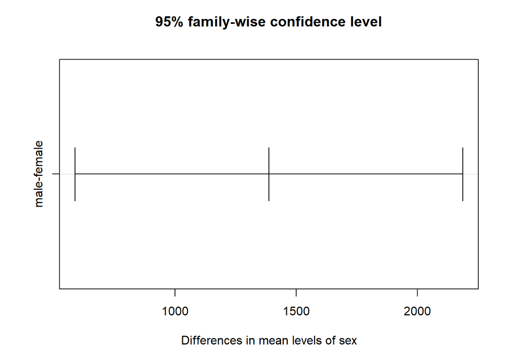

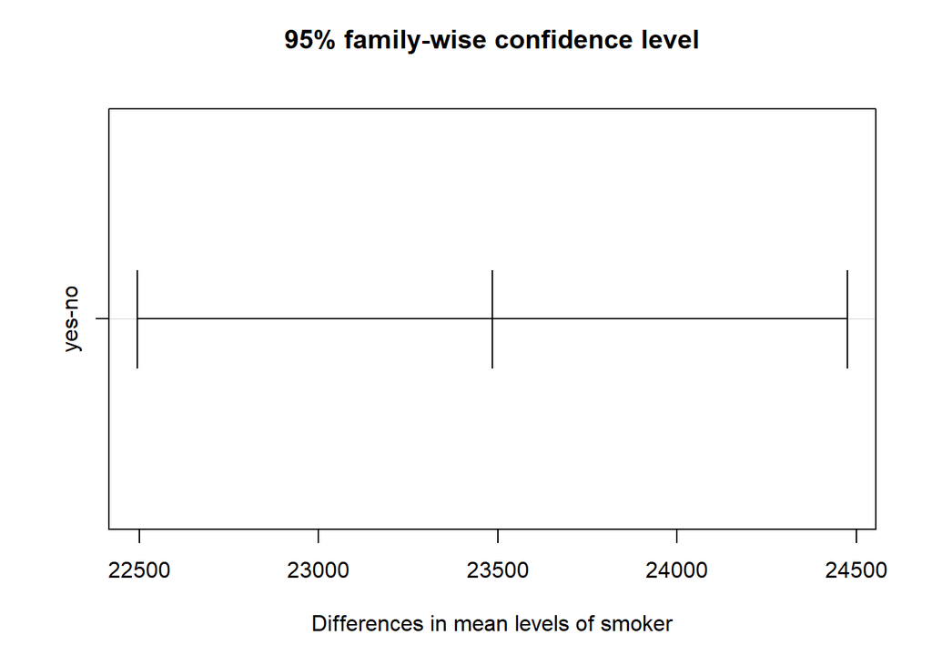

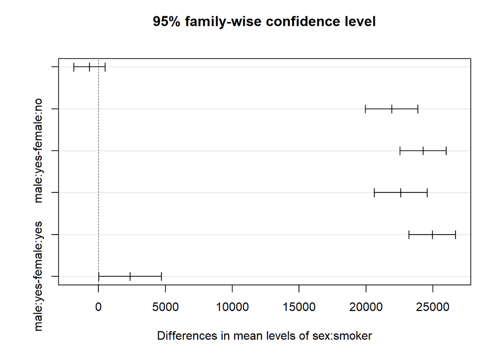

```r
plot(TukeyHSD(aov(charges ~ sex * smoker, data = data)))
```

The Tukey’s HSD test provides pairwise comparisons of means with confidence intervals and adjusted p-values:

Males have higher charges than females by 1,387.172 units. Smokers have significantly higher charges than non-smokers by 23,485.03 units. For the interaction between sex and smoking status:

Smoking males have significantly higher charges than non-smoking females by 24,279.7087 units. Smoking females have significantly higher charges than non-smoking males by 22,591.7915 units. Among non-smokers, males have lower charges than females by 675.0926 units. Among smokers, males have significantly higher charges than females by 2,363.0097 units. Among males, smokers have significantly higher charges than non-smokers by 24,954.8012 units. Among females, smokers have significantly higher charges than non-smokers by 21,916.6990 units.